# Podatkovno progamiranje Tutorial 7/Vaje 7

Peter Muršič 2022

```r
library(tidyverse)
```

### EN

##### A

1. Draw y$\sim$x using a scatterplot, with plot, lattice, and ggplot2.

   ```r
   n<-1000
   x<-(1:n-1)^((sqrt(5)-1)/2)*cos((1:n-1)*2*pi*(sqrt(5)-1)/2)
   y<-(1:n-1)^((sqrt(5)-1)/2)*sin((1:n-1)*2*pi*(sqrt(5)-1)/2)
   ```

2. Plot the sinus function on the interval $[-\pi,\pi]$.
3. Plot a circle of radius 1 around the origin. Add a title and x,y labels. Plot a square on top of it.

**Toggle output**

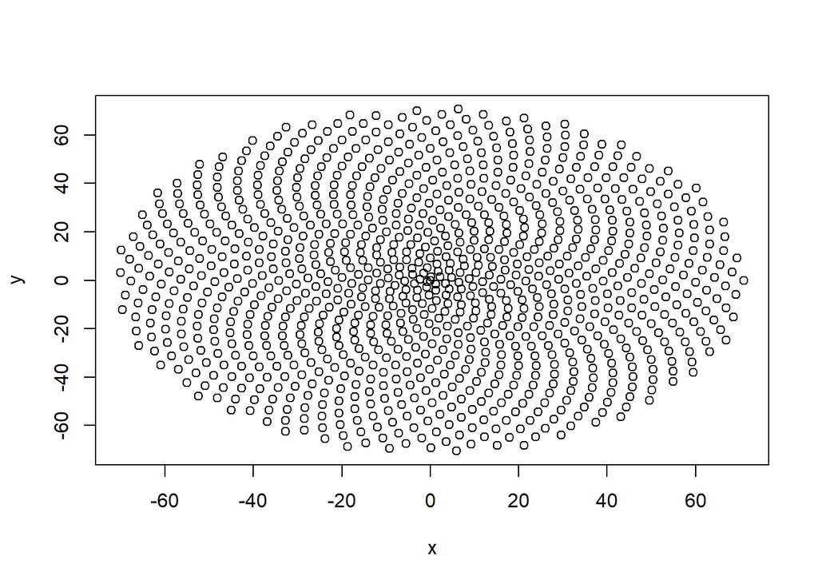

```r
plot(x,y)
```

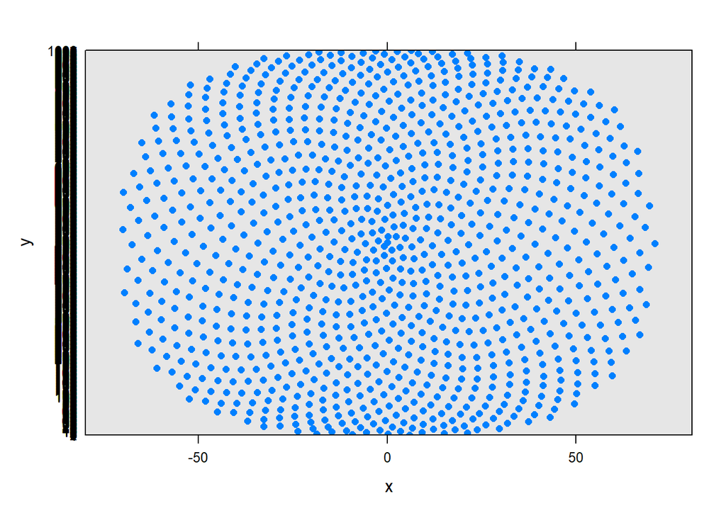

```r
lattice::dotplot(y~x)
```

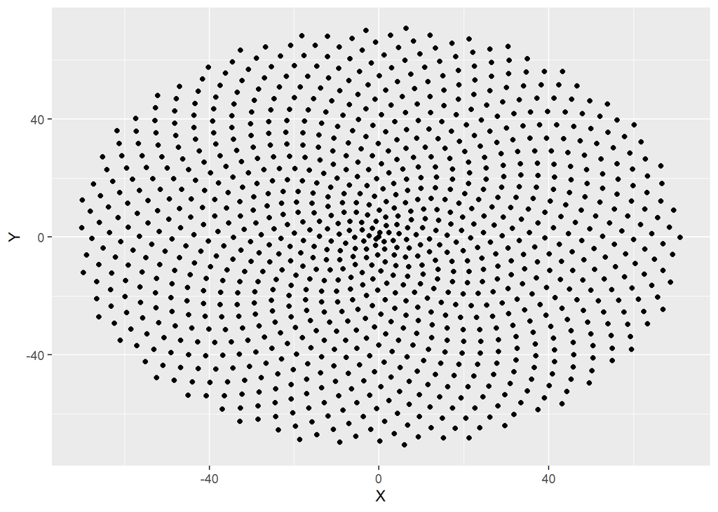

```r
data.frame(X=x,Y=y) %>% ggplot()+aes(x=X,y=Y)+geom_point()
```

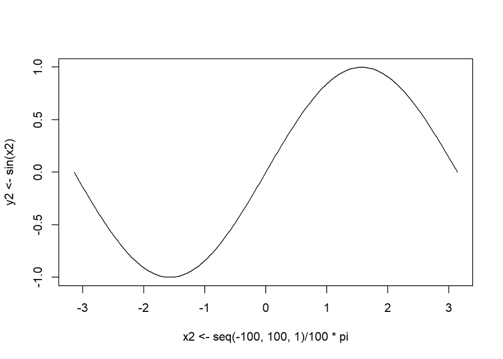

```r
plot(x2<-seq(-100,100,1)/100*pi,y2<-sin(x2),type='l')
```

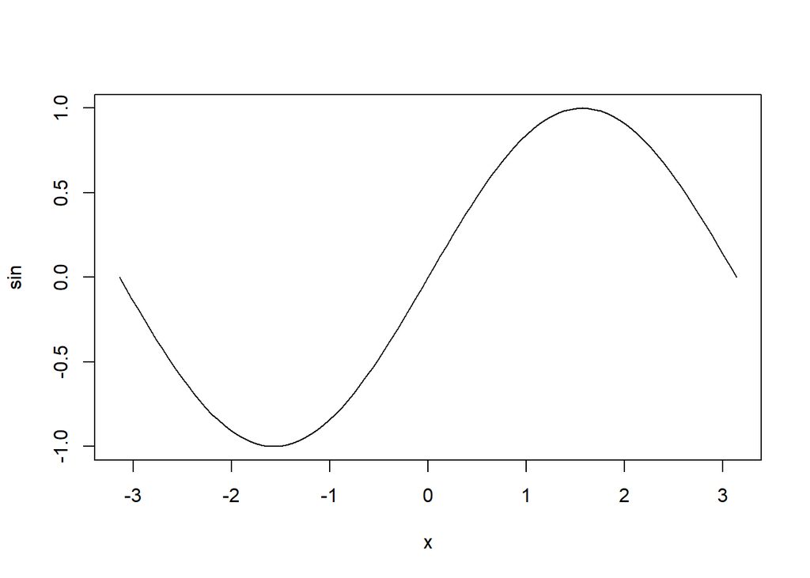

```r
plot(sin, -pi, pi)
```

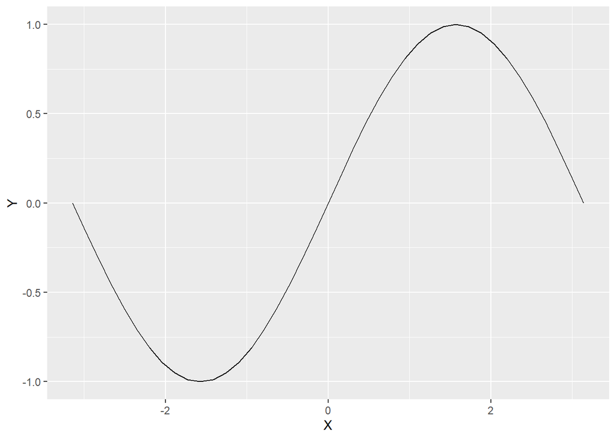

```r
(seq(-1,1,0.05)*pi) %>% data.frame(X=.,Y=sin(.)) %>% ggplot()+aes(x=X,y=Y)+geom_line()
```

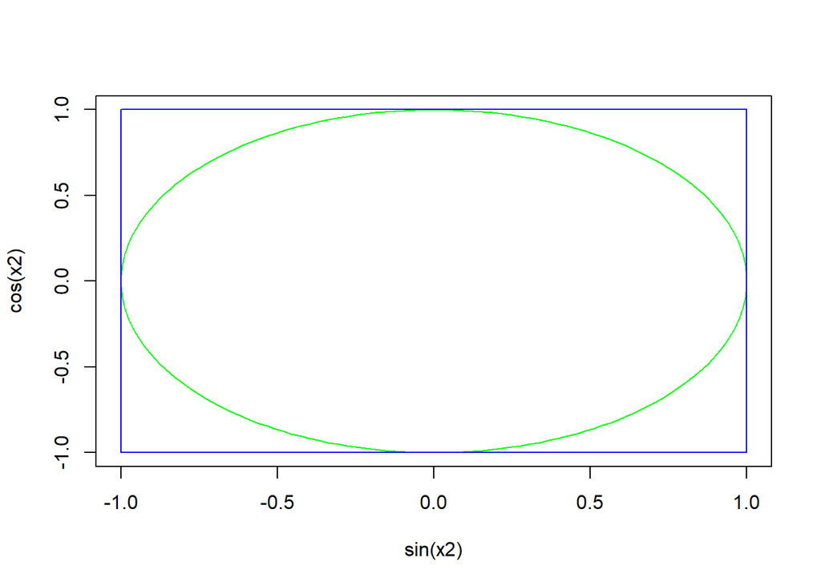

```r
x2<-seq(-100,100,1)/100*pi
plot(sin(x2),cos(x2),type='l',col="green")
lines(c(1,1,-1,-1,1),c(1,-1,-1,1,1),type='l',col="blue")
```

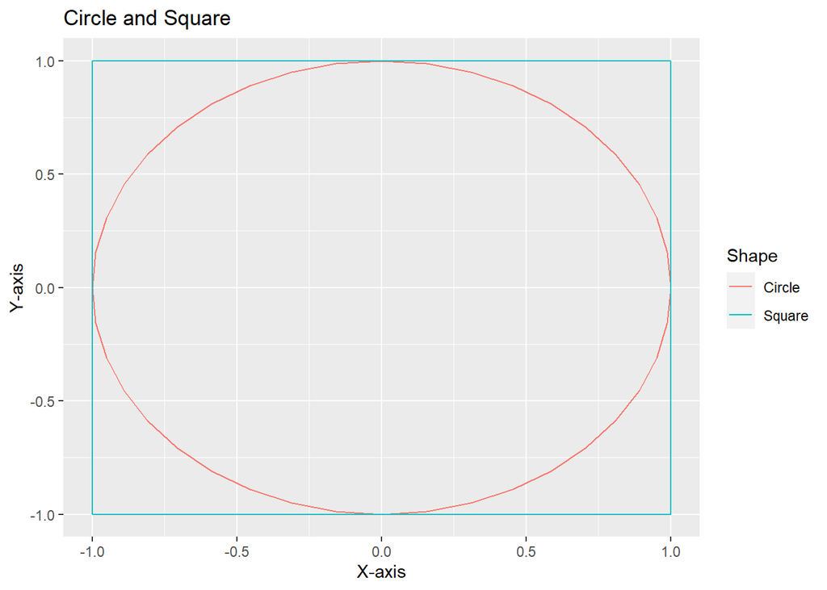

```r
(seq(-1,1,0.05)*pi) %>% {data.frame(X=c(cos(.),c(1,-1,-1,1,1)),Y=c(sin(.),c(1,1,-1,-1,1)),Shape=rep(c("Circle","Square"),c(length(.),5)))} %>% ggplot() + aes(x = X, y = Y, colour = Shape, group = Shape) + geom_path()  + labs(x = "X-axis", y = "Y-axis", title = "Circle and Square")
```

##### B

1. Create a function that given a positive integer $n$ it creates n points at random in the square $[-1,1]\times [-1,1]$ then counts how many lie in the unit circle (radius=1) around the origin (0,0). The function should return 4*count/n and should also plot the random points, the square and the circle on the same plot. Color the inside points with a different color then outside points. Help yourself with the function from the last tutorial:

   ```r
   incircle<-(function(x,y) sqrt(x^2+y^2)<=1)
   ```

2. Take the ggplot from the first problem and decrease the size of the point closer to the origin and also color based on distance from the origin, like a sunflower.

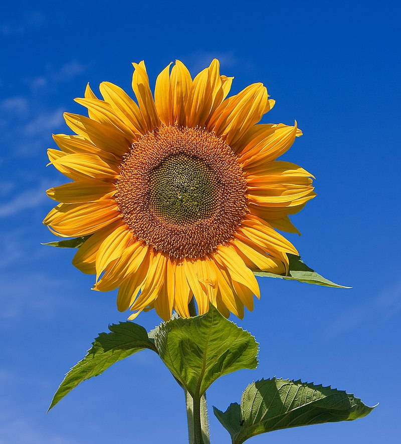

**Toggle output**

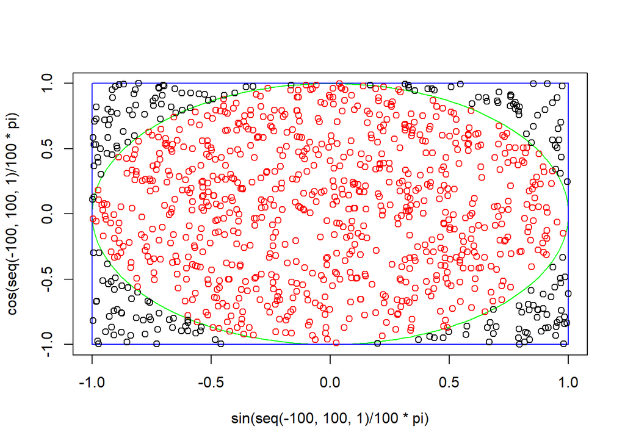

```
## [1] 3.132
```

```r
isitpi<-function(n=100){
  x<-runif(n,-1,1)
  y<-runif(n,-1,1)
  incircle<-(function(x,y)sqrt(x^2+y^2)<=1)
  count<-sum(incircle(x,y))
  plot(sin(seq(-100,100,1)/100*pi),cos(seq(-100,100,1)/100*pi),type='l',col="green")
  lines(c(1,1,-1,-1,1),c(1,-1,-1,1,1),type='l',col="blue")
  points(x,y,col=ifelse(incircle(x,y),'red','black'))
  return(4*count/n)
}
isitpi(1000)
```

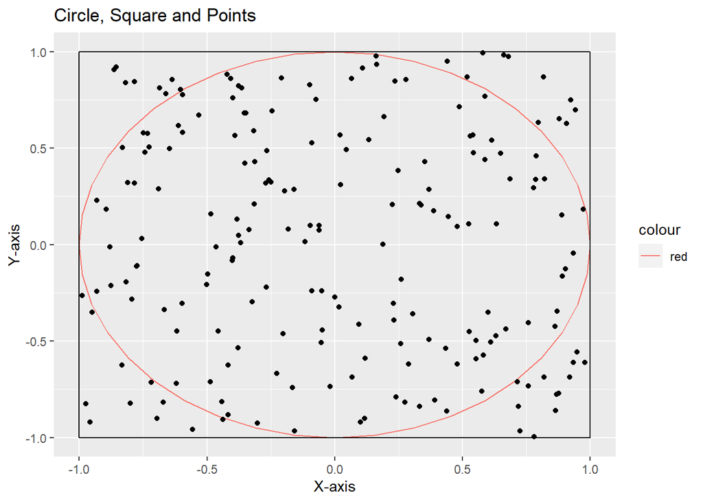

```
## [1] 3.14
```

```r
montecarlo<-\(n){
  runif(n,-1,1)->x
  runif(n,-1,1)->y
  (seq(-1,1,0.05)*pi) %>% {data.frame(X=cos(.),Y=sin(.))}  %>% {ggplot(.)+geom_path(aes(x=X,y=Y,color="red")) + labs(x = "X-axis", y = "Y-axis", title = "Circle, Square and Points")+ geom_path(data=data.frame(X=c(1,-1,-1,1,1),Y=c(1,1,-1,-1,1)),aes(x=X,y=Y))+geom_point(data=data.frame(X=x,Y=y),aes(x=X,y=Y))} %>% print()
  (sqrt(x^2+y^2)<=1) %>% sum() %>% {.*4/n}
}
montecarlo(200)
```

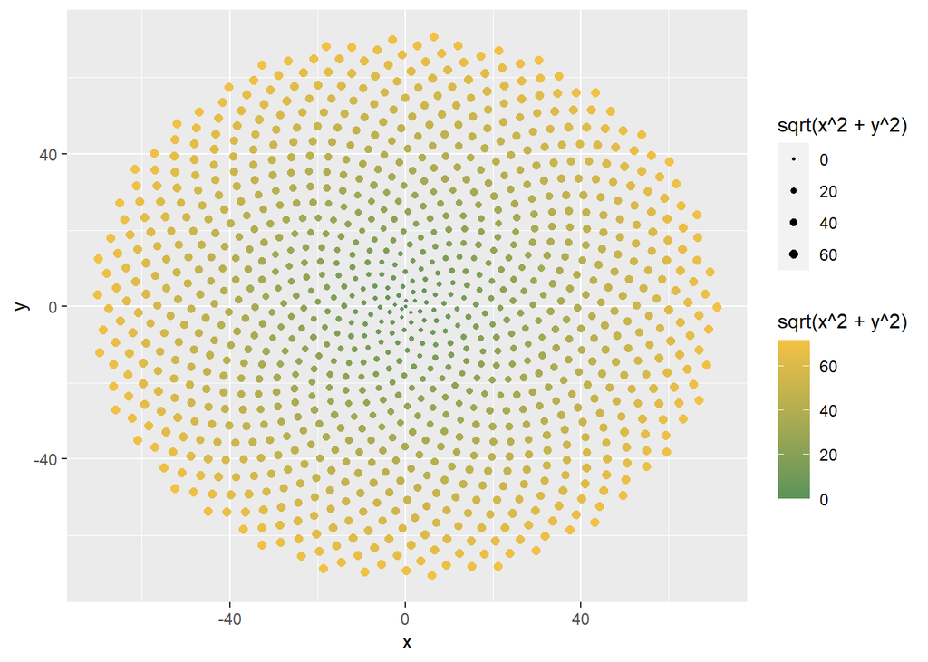

```r
data.frame(X=x,Y=y) %>% ggplot()+
  geom_point(aes(x,y,colour=sqrt(x^2+y^2), size = sqrt(x^2+y^2)))+scale_size_continuous(range = c(0.5,2))+scale_color_gradient(low = "#58935A", high = "#F3C145")
```

##### C

1. Ggplot the petal length in the dataframe iris with a histogram. Color the species in different colors. How do you plot only 1 species instead of all 3?

**Toggle output**

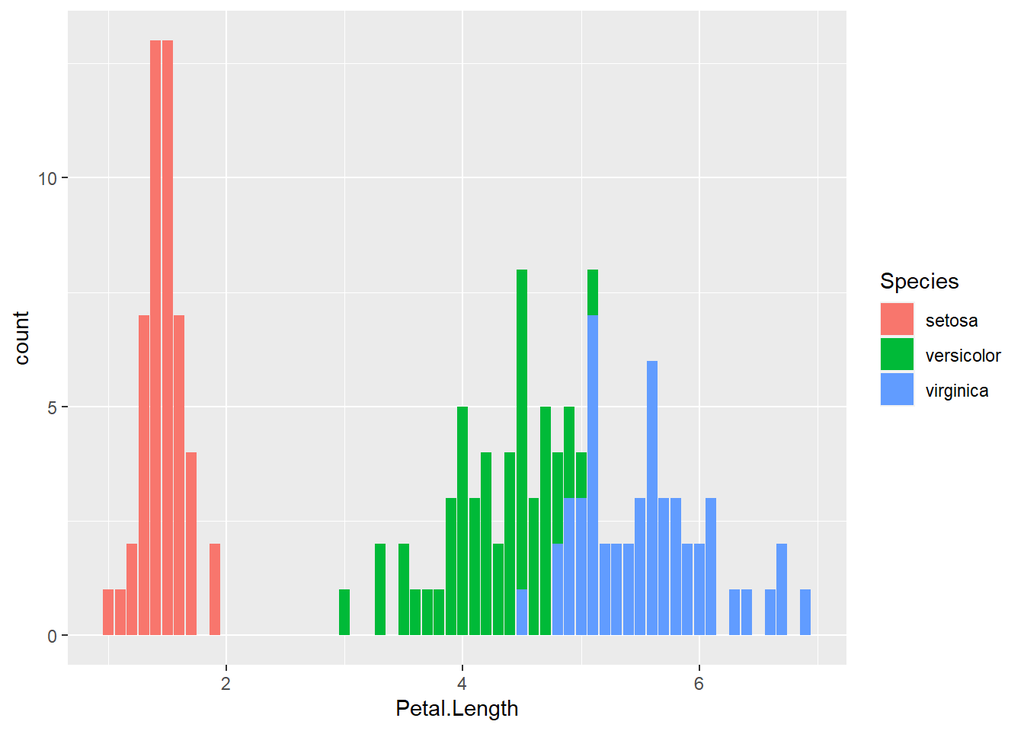

```r
ggplot(iris,aes(x=Petal.Length, fill=Species))+geom_bar()
```

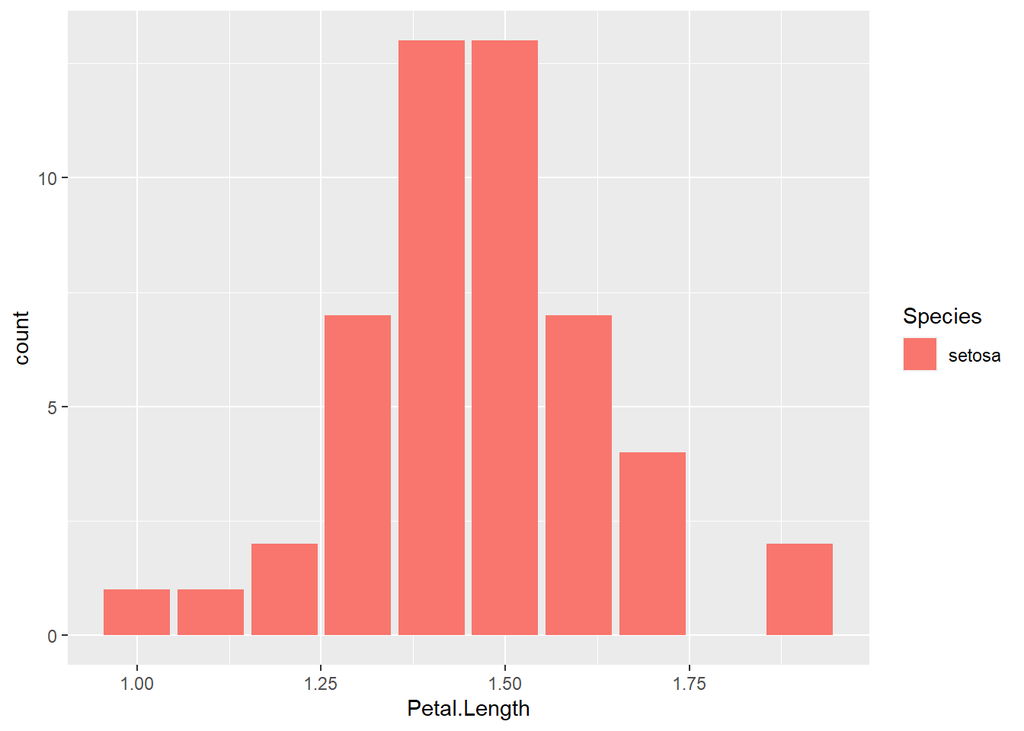

```r
ggplot(iris[iris$Species=="setosa",],aes(x=Petal.Length, fill=Species))+geom_bar()
```

##### D

- Pie chart with ggplot:

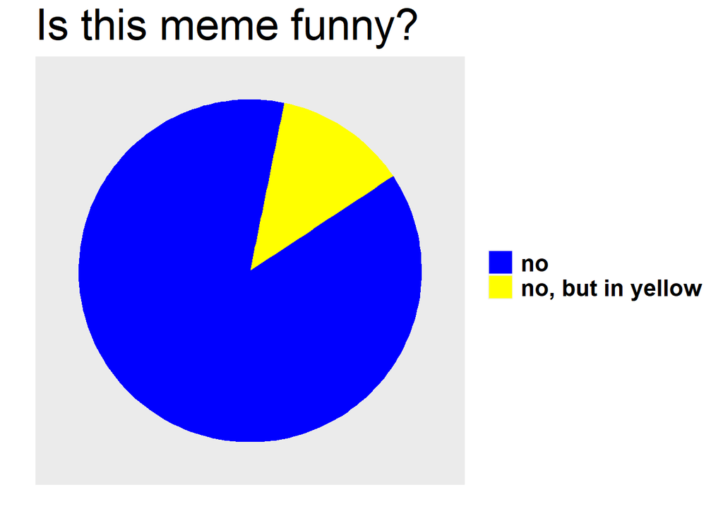

```r
dfB1<-data.frame(labels=c("no","no, but in yellow"),"values"=c(7,1))
ggplot(dfB1, aes(x="", y=values,fill=labels))+
  geom_bar(width = 1, stat = "identity")+coord_polar("y", start=0.2)+
  scale_fill_manual(values=c("blue", "yellow"))+
  #  ggtitle("Is this meme funny?")
  labs(title="Is this meme funny?",x="",y="")+
  theme(plot.title = element_text(size=30),
        axis.text = element_blank(),
        axis.ticks = element_blank(),
        panel.grid  = element_blank(),
        legend.title=element_blank(),
        legend.text = element_text(size = 16, face = "bold"))
```

### SLO

##### A

1. Nariši y$\sim$x z raztresenim grafikonom z uporabo plot, lattice in ggplot2.

   ```r
   n<-1000
   x<-(1:n-1)^((sqrt(5)-1)/2)*cos((1:n-1)*2*pi*(sqrt(5)-1)/2)
   y<-(1:n-1)^((sqrt(5)-1)/2)*sin((1:n-1)*2*pi*(sqrt(5)-1)/2)
   ```

2. Nariši funkcijo sinus na intervalu $[-\pi,\pi]$.
3. Nariši krožnico s polmerom 1 okoli izhodišča. Dodaj naslov in pre/poimenuj $x$ os in $y$ os. Nariši še kvadrat na isto sliko.

**Toggle output**

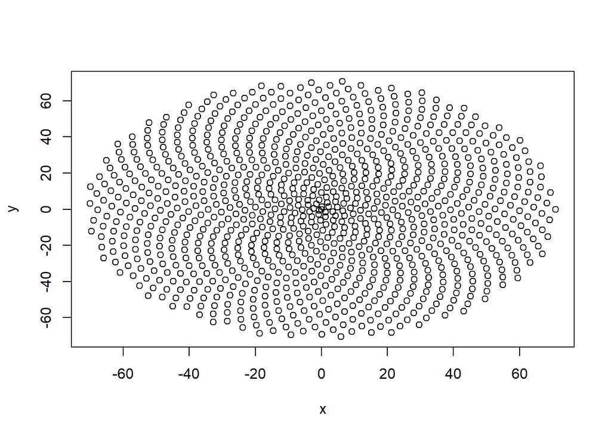

```r
plot(x,y)
```

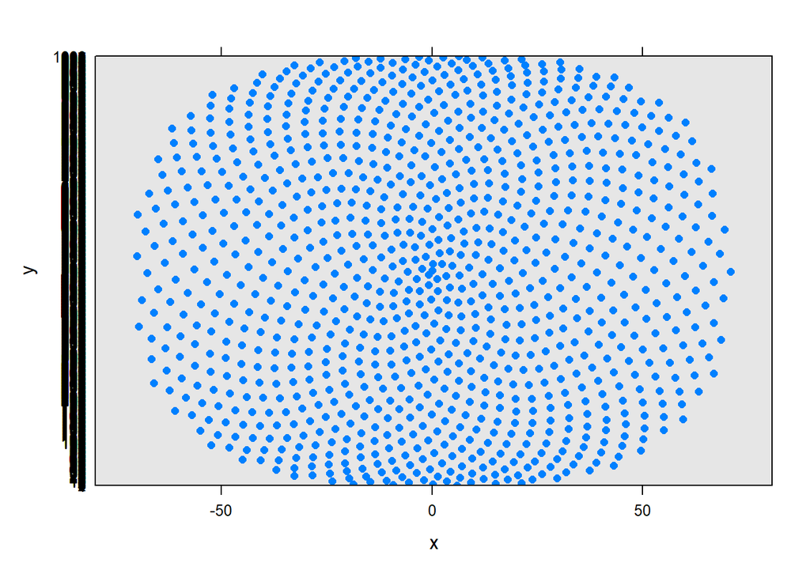

```r
lattice::dotplot(y~x)
```

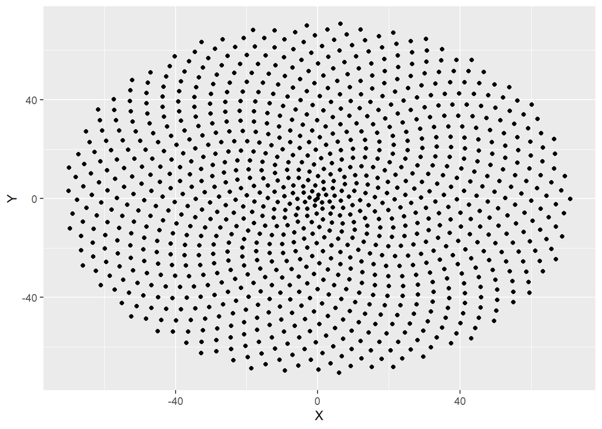

```r
data.frame(X=x,Y=y) %>% ggplot()+aes(x=X,y=Y)+geom_point()
```

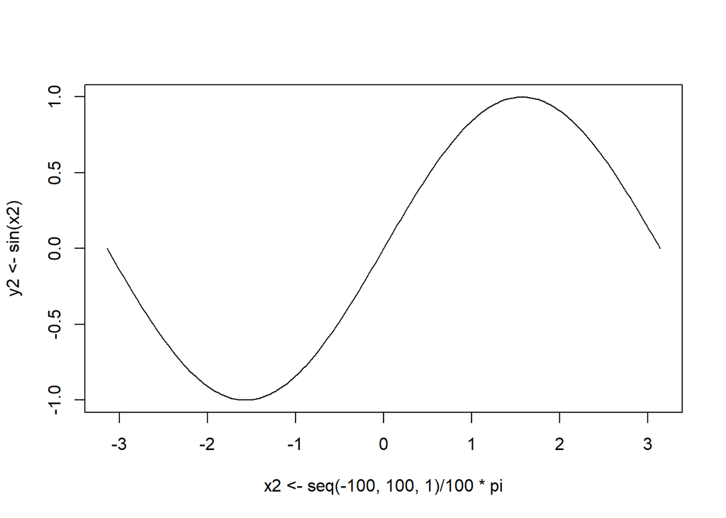

```r
plot(x2<-seq(-100,100,1)/100*pi,y2<-sin(x2),type='l')
```

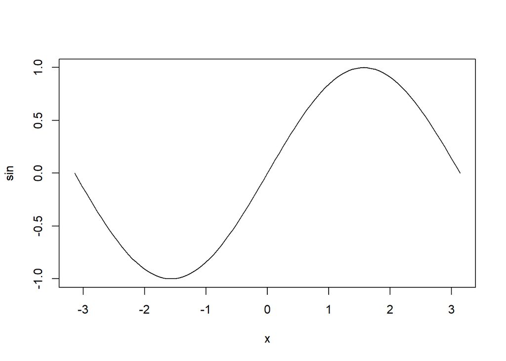

```r
plot(sin, -pi, pi)
```

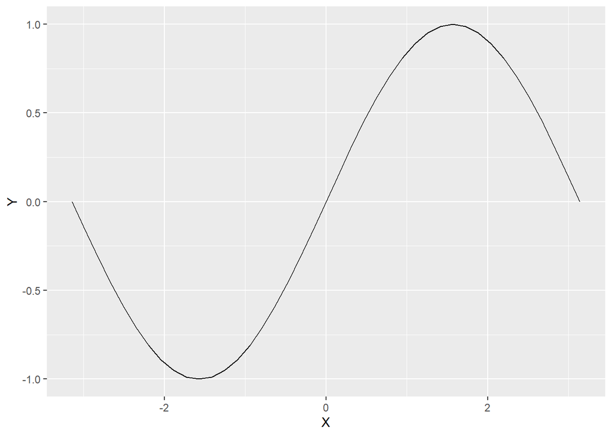

```r
(seq(-1,1,0.05)*pi) %>% data.frame(X=.,Y=sin(.)) %>% ggplot()+aes(x=X,y=Y)+geom_line()
```

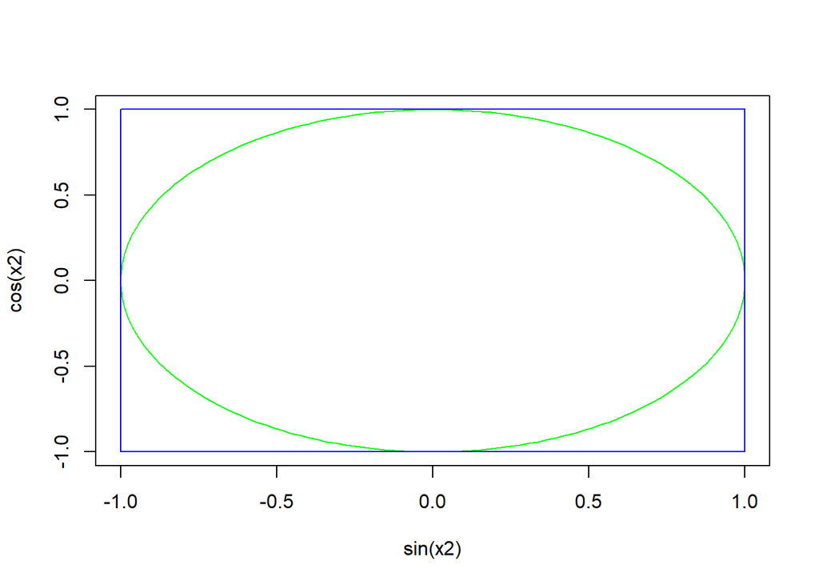

```r
x2<-seq(-100,100,1)/100*pi
plot(sin(x2),cos(x2),type='l',col="green")
lines(c(1,1,-1,-1,1),c(1,-1,-1,1,1),type='l',col="blue")
```

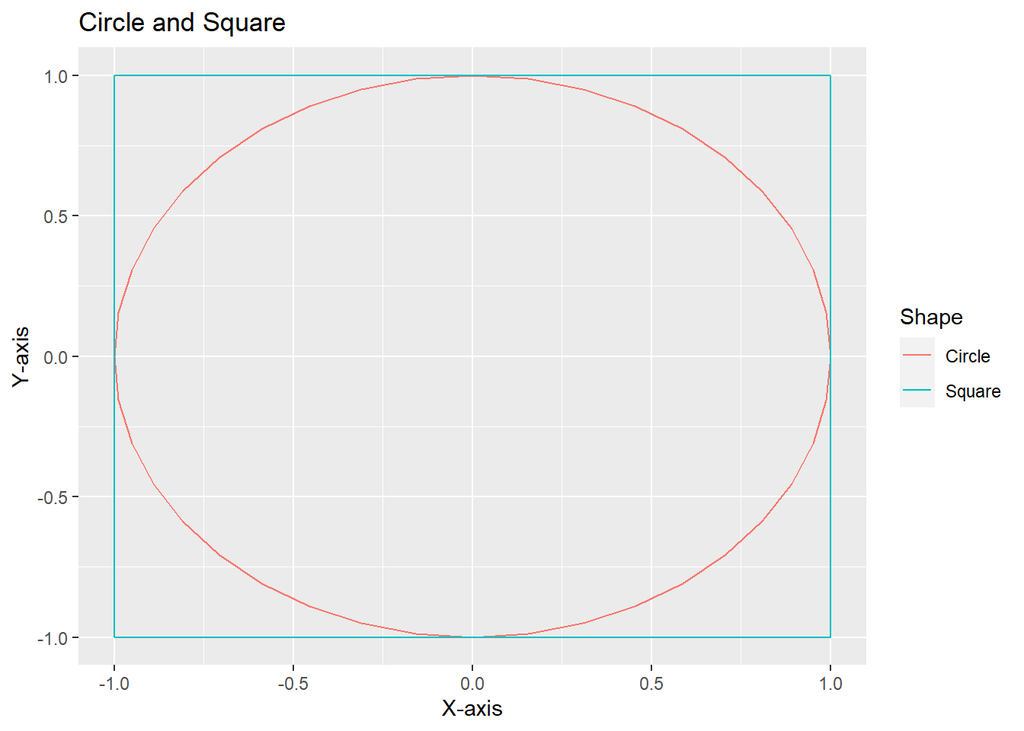

```r
(seq(-1,1,0.05)*pi) %>% {data.frame(X=c(cos(.),c(1,-1,-1,1,1)),Y=c(sin(.),c(1,1,-1,-1,1)),Shape=rep(c("Circle","Square"),c(length(.),5)))} %>% ggplot() + aes(x = X, y = Y, colour = Shape, group = Shape) + geom_path()  + labs(x = "X-axis", y = "Y-axis", title = "Circle and Square")
```

##### B

1. Napiši funkcijo, ki ima za vhodni parameter naravno število $n$ in zgenerira $n$ točk po naključju znotraj kvadrata $[-1,1]\times [-1,1]$, in nato prešteje koliko od teh točk leži znotraj ali na krožnici. Funkcija naj vrne kot rezultat 4*prešteto/n. Poleg tega naj tudi izriše s funkcijo plot vse točke, krožnico in kvadrat. Pobarvaj točke znotraj krožnice z drugo barvo. Lahko si pomagate s funkcijo iz prejšnji vaj:

   ```r
   incircle<-(function(x,y) sqrt(x^2+y^2)<=1)
   ```

2. GGplotu iz prve naloge dodajte še barve, na podlagi razdalj od izhodišča in tudi na podlagi istih razdalj še povečajte oziroma zmajšajte točke, kot pri sončnici.

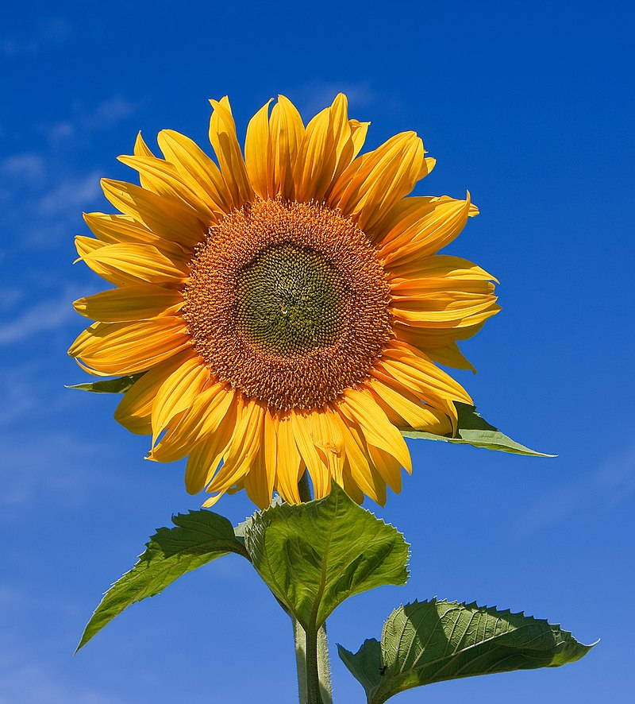

**Toggle output**

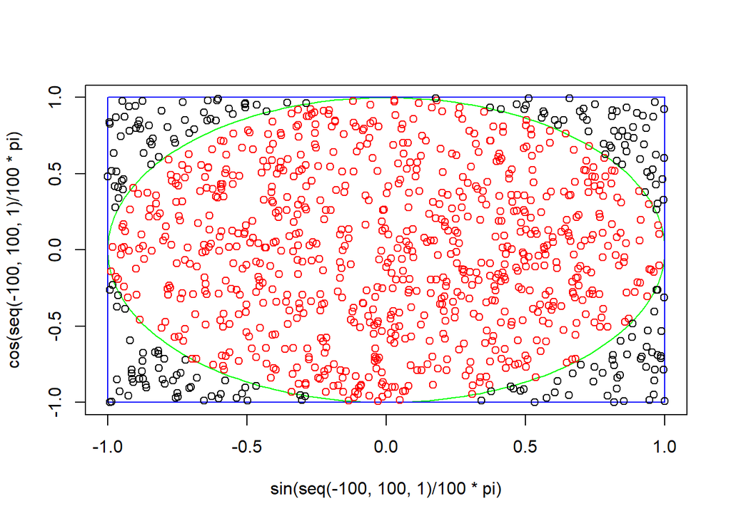

```
## [1] 3.144
```

```r
isitpi<-function(n=100){
  x<-runif(n,-1,1)
  y<-runif(n,-1,1)
  incircle<-(function(x,y)sqrt(x^2+y^2)<=1)
  count<-sum(incircle(x,y))
  plot(sin(seq(-100,100,1)/100*pi),cos(seq(-100,100,1)/100*pi),type='l',col="green")
  lines(c(1,1,-1,-1,1),c(1,-1,-1,1,1),type='l',col="blue")
  points(x,y,col=ifelse(incircle(x,y),'red','black'))
  return(4*count/n)
}
isitpi(1000)
```

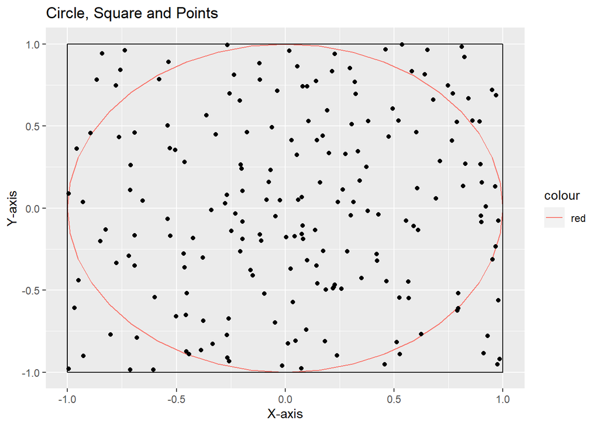

```
## [1] 3.18
```

```r
montecarlo<-\(n){
  runif(n,-1,1)->x
  runif(n,-1,1)->y
  (seq(-1,1,0.05)*pi) %>% {data.frame(X=cos(.),Y=sin(.))}  %>% {ggplot(.)+geom_path(aes(x=X,y=Y,color="red")) + labs(x = "X-axis", y = "Y-axis", title = "Circle, Square and Points")+ geom_path(data=data.frame(X=c(1,-1,-1,1,1),Y=c(1,1,-1,-1,1)),aes(x=X,y=Y))+geom_point(data=data.frame(X=x,Y=y),aes(x=X,y=Y))} %>% print()
  (sqrt(x^2+y^2)<=1) %>% sum() %>% {.*4/n}
}
montecarlo(200)
```

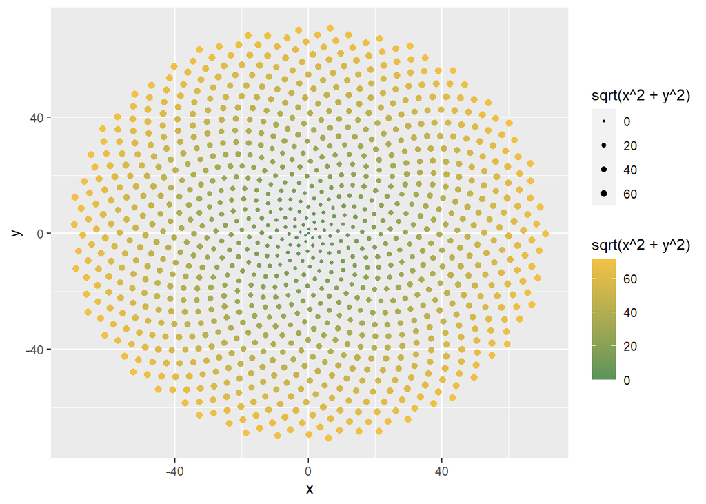

```r
data.frame(X=x,Y=y) %>% ggplot()+
  geom_point(aes(x,y,colour=sqrt(x^2+y^2), size = sqrt(x^2+y^2)))+scale_size_continuous(range = c(0.5,2))+scale_color_gradient(low = "#58935A", high = "#F3C145")
```

##### C

1. Nariši velikost cvetov (Petal.Length) v dataframeu iris s histogramom. Pobarvaj različne vrste z drugačnimi barvami. Kako bi narisali samo 1 vrsto namesto vseh 3?

**Toggle output**

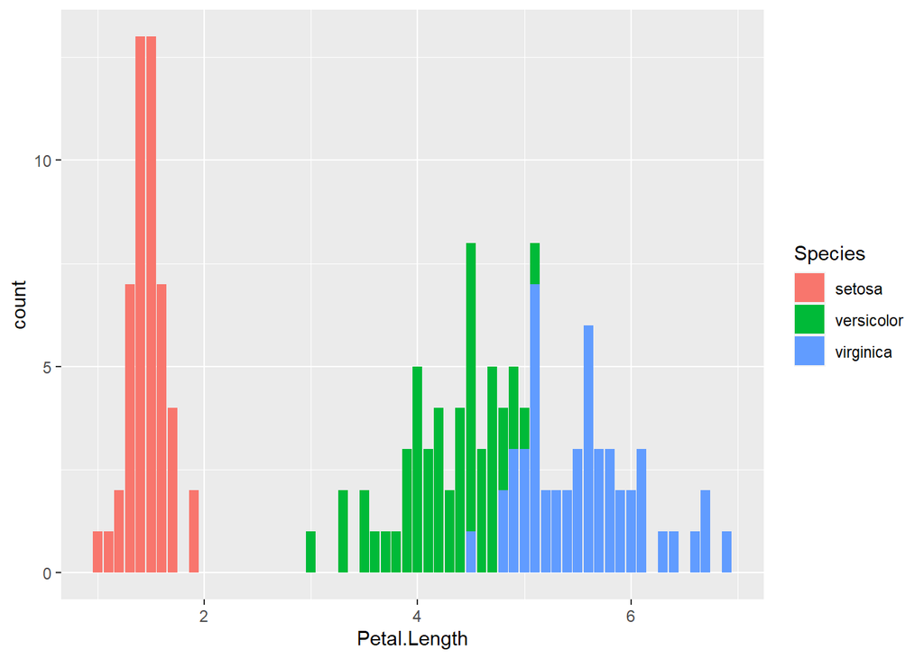

```r
ggplot(iris,aes(x=Petal.Length, fill=Species))+geom_bar()
```

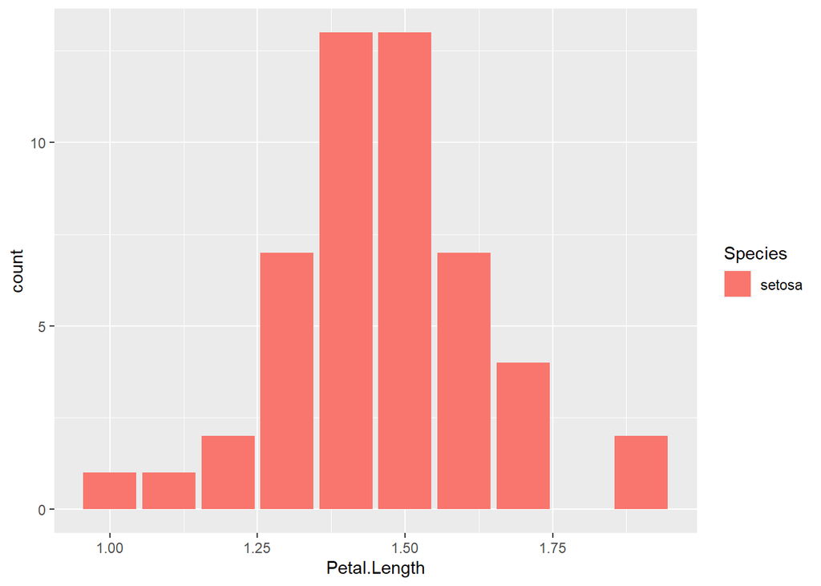

```r
ggplot(iris[iris$Species=="setosa",],aes(x=Petal.Length, fill=Species))+geom_bar()
```

##### D

- Tortni grafikon z ggplot:

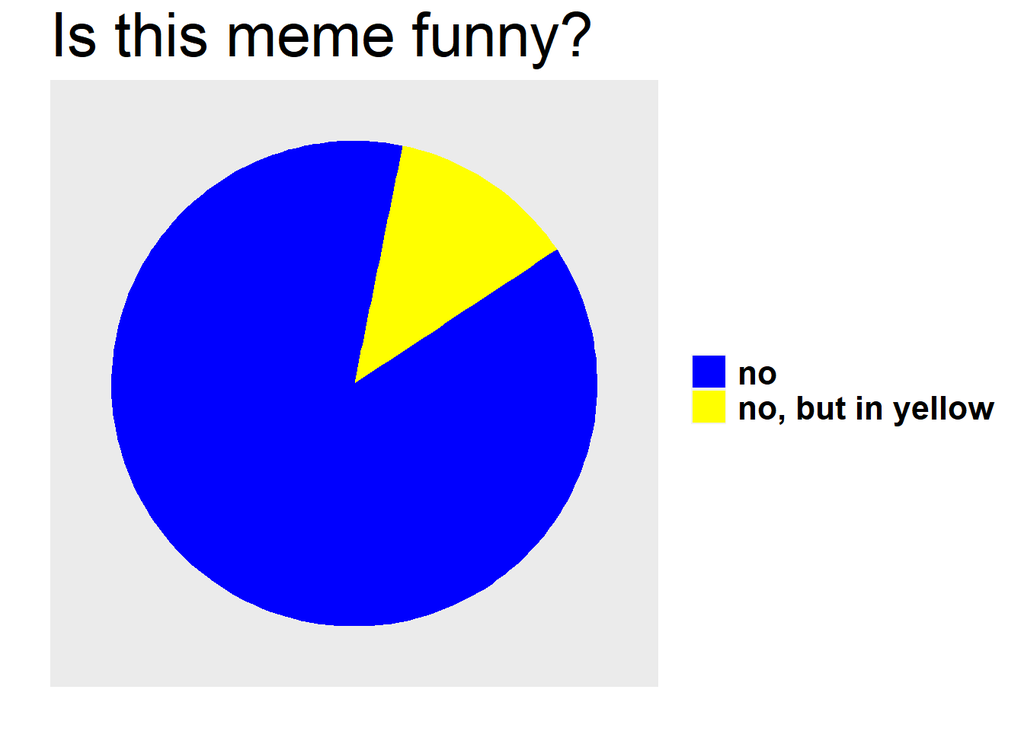

```r
dfB1<-data.frame(labels=c("no","no, but in yellow"),"values"=c(7,1))
ggplot(dfB1, aes(x="", y=values,fill=labels))+
  geom_bar(width = 1, stat = "identity")+coord_polar("y", start=0.2)+
  scale_fill_manual(values=c("blue", "yellow"))+
  #  ggtitle("Is this meme funny?")
  labs(title="Is this meme funny?",x="",y="")+
  theme(plot.title = element_text(size=30),
        axis.text = element_blank(),
        axis.ticks = element_blank(),
        panel.grid  = element_blank(),
        legend.title=element_blank(),
        legend.text = element_text(size = 16, face = "bold"))
```

### Exploratory data analysis

In statistics, exploratory data analysis is an approach to analyzing data sets to summarize their main characteristics, often using statistical graphics and other data visualization methods

##### GGplot

The typical scatterplots, histograms, line charts, pie charts will work as long as you are presenting aggregation of the data in a compact form, for example:

```
## # A tibble: 22 × 3
##    Brand      MPG    HP
##    <chr>    <dbl> <dbl>
##  1 AMC       15.2   150
##  2 Cadillac  10.4   205
##  3 Camaro    13.3   245
##  4 Chrysler  14.7   230
##  5 Datsun    22.8    93
##  6 Dodge     15.5   150
##  7 Duster    14.3   245
##  8 Ferrari   19.7   175
##  9 Fiat      29.8    66
## 10 Ford      15.8   264
## # ℹ 12 more rows
```

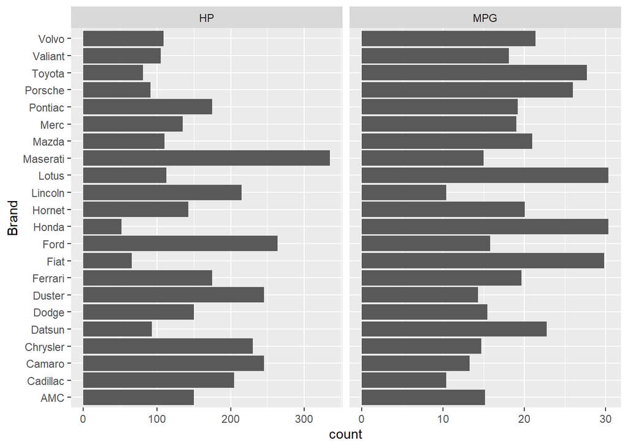

```r
mtcars %>% mutate(Brand=str_extract(rownames(.),"[^ ]*")) %>% group_by(Brand) %>% summarise(MPG=mean(mpg),HP=mean(hp)) %>% {print(.);.} %>% pivot_longer(2:3) %>% ggplot()+aes(y=Brand,weight=value)+geom_bar() +facet_wrap(vars(name),scales = "free_x")
```

##### Linear regression

In statistics, linear regression is a linear approach to modelling the relationship between a scalar response and one or more explanatory variables (also known as dependent and independent variables)

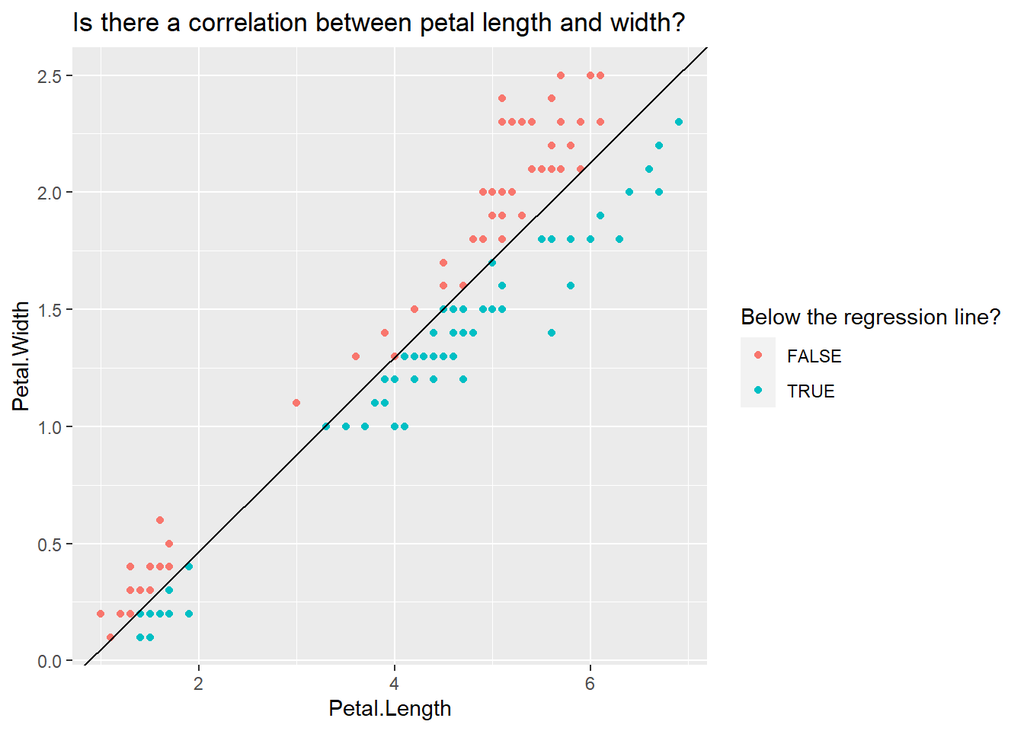

```r
coeff<-lm(iris$Petal.Width~iris$Petal.Length)
ggplot(iris,aes(Petal.Length,Petal.Width,color=(Petal.Length*coeff[[1]][2]+coeff[[1]][1]>Petal.Width)))+geom_point()+geom_abline(intercept=coeff[[1]][1],slope=coeff[[1]][2])+
  labs(color = "Below the regression line?",title="Is there a correlation between petal length and width?")
```

A horizontal line would imply y does not depend on x, hence no correlation, a steep line would imply a strong correlation.